# Predicting Employee Burnout Rate in a Post-Pandemic World

8/6/2021

# Introduction

Worker burnout is an ongoing concern on both sides of the labor market. Workers naturally want to avoid burnout for their own career success and quality of life, and employers must be concerned about the negative effects of burnout on productivity and employee retention. And the problem of worker burnout has only been intensified by a global pandemic that has upended the way we live and work, and further blurred the already blurring lines between work and personal life. As workers and students trying to navigate this unique period in history, we also felt great personal interest in studying this problem!

In this project we aim to use statistical methods to create a model to predict employee burnout. We intend to balance raw predictive power with model simplicity and interpretability. This is is so that this model is useful not only in post hoc prediction of burnout (i.e. burnout that has already happened), but also as a tool to help employees and employers learn how they can prevent burnout in the first place by controlling the key factors that contribute to burnout.

This dataset has 9 variables in total, including 5 continuous variables (Date of Joining, Designation, Resources Allocation, Mental Fatigue Score and Burn Rate) and 4 categorical variables (employee ID, Gender, Company Type, WFH Setup Available).

- `Employee ID`: The unique ID allocated for each employee (example: fffe390032003000)
- `Date of Joining`: The date-time when the employee joined the organization (example: 2008-12-30)
- `Gender`: The gender of the employee (Male/Female)
- `Company Type`: The type of company where the employee is working (Service/Product)
- `WFH Setup Available`: Availability of proper Work From Home setup (Yes/No)
- `Designation`: The seniority of the employee within the organization.
  - Range is [0.0, 5.0] where higher number corresponds to higher designation.
- `Resource Allocation`: Work hours allocated per day.
  - Range is [1.0, 10.0]
- `Mental Fatigue Score`: Self-reported employee stress level
  - Range is [0.0, 10.0] where 0.0 means no stress/fatigue and 10.0 means complete stress/fatigue.
- `Burn Rate`: Rate of saturation or burnout while working.
  - Range is [0.0, 1.0] where higher number corresponds to more burn out.

The dataset was obtained from a kaggle contest titled “Are Your Employees Burning Out”, which can be accessed [here](https://www.kaggle.com/blurredmachine/are-your-employees-burning-out).  
*Please note that the original HackerEarth competiton is no longer accessible.*

We translate our high-level goals for this analysis into the following four specific modeling goals:

- Adjusted R-squared > 90%
- Model simple enough to be interpretable
- Meets the ‘Normality’ assumption of linear regression
- Meets the ‘Equal Variance’ assumption of linear regression

# Methods

### Setup & Modeling Preparation

```r
# load packages
library(faraway)
library(readr)
library(lmtest)
library(leaps)
library(knitr)
```

We begin by loading in the data and cleaning it.  
*Please note that for purposes of report body brevity, this is a condensed cleaning script; to see the complete EDA process and development of this final cleaning script, please refer to the Appendix.*

```r
train = read_csv("train_cleaned.csv")
train$Gender = factor(train$Gender)
train$'Type' = factor(train$'Type')
train$'WFH' = factor(train$'WFH')
train  = train[-1]  # drop ID - no relevance to training or results for this task
train_complete = na.exclude(train) # exclude NA for ease of data manipulation and modeling
str(train_complete)
```

```
## tibble [18,590 × 8] (S3: tbl_df/tbl/data.frame)
##  $ Gender     : Factor w/ 2 levels "Female","Male": 1 2 2 1 2 1 1 2 2 2 ...
##  $ Type       : Factor w/ 2 levels "Product","Service": 2 2 2 2 1 2 2 1 2 1 ...
##  $ WFH        : Factor w/ 2 levels "No","Yes": 1 2 2 1 2 1 2 2 2 2 ...
##  $ Designation: num [1:18590] 2 1 1 3 2 3 2 2 0 1 ...
##  $ Resource   : num [1:18590] 3 2 1 7 4 6 4 3 1 3 ...
##  $ Fatigue    : num [1:18590] 3.8 5 2.6 6.9 3.6 7.9 4.4 5.3 1.8 5.8 ...
##  $ Burn       : num [1:18590] 0.16 0.36 0.2 0.52 0.29 0.62 0.33 0.5 0.12 0.51 ...
##  $ Days       : num [1:18590] 92 31 58 160 35 364 61 290 233 231 ...
##  - attr(*, "na.action")= 'exclude' Named int [1:3036] 3 9 10 13 14 20 24 25 26 30 ...
##   ..- attr(*, "names")= chr [1:3036] "3" "9" "10" "13" ...
```

Next, we define a diagnostics function to quickly check the LINE assumptions and calculate model evaluation metrics, including adjusted R-squared, LOOCV, and BIC. (*BIC is chosen over AIC since we are prioritizing interpretability/model simplicity in our modeling goals.*)

```r
diagnostics = function(model, pcol = 'grey', lcol = 'dodgerblue', alpha = 0.05,
                       plotit = TRUE, testit = TRUE) {

  if (plotit) {
    par(mfrow = c(1, 2))
    plot(fitted(model), resid(model), xlab = 'Fitted', ylab = 'Residuals',
         col = pcol, pch = 20, cex = 2)
    abline(h = 0, col = lcol, lwd = 3, main = "Fitted vs Residuals")

    qqnorm(resid(model), col = pcol, pch = 20, cex = 1,
           main = "Normal Q-Q plot")
    qqline(resid(model), col = lcol, lwd = 3)
  }

  if (testit) {
    p_val_bp = as.numeric(bptest(model)$p.value)
    p_val = shapiro.test(resid(model))$p.value
    adj_r = summary(model)$adj.r.squared
    loocv = sqrt(mean((resid(model) / (1 - hatvalues(model))) ^ 2, na.rm = TRUE))
    n = length(resid(model))
    bic = extractAIC(model, k = log(n))[2]
    data.frame(bptest = p_val_bp, shapiro.test = p_val, adj.r.squared = adj_r, loocv = loocv, BIC = bic)
  }
}
```

We randomly select 1000 rows for selection testing. This will allow us to us fit many different models and perform the Shapiro-Wilk test (which is limited in sample size).

```r
sel_size = 1000
set.seed(2021)
train = train_complete[sample(nrow(train_complete), sel_size),]
nrow(train)
```

```
## [1] 1000
```

### Simple Additive Model

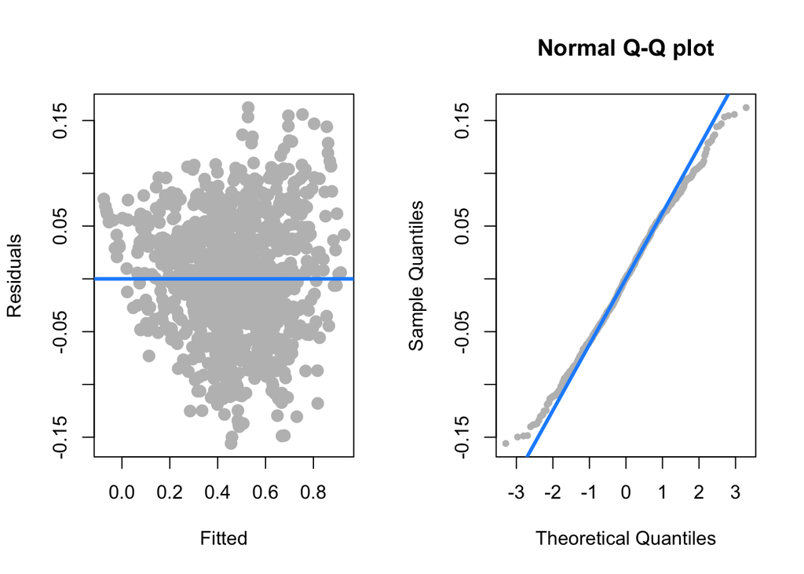

```
##         bptest shapiro.test adj.r.squared      loocv       BIC
## 1 5.779568e-05   0.01680973     0.9177178 0.05797158 -5655.874
```

```r
mod_add = lm(Burn ~ ., data = train)
diagnostics(mod_add)
```

```r
summary(mod_add)$adj.r.squared
```

```
## [1] 0.9177178
```

### Collinearity

Check the model for collinearity. If any is identified, it will be crucial to resolve it if we want our model to be interpretable/prescriptive and not only predictive. First, we check visually with a pairs plot of all the variables:

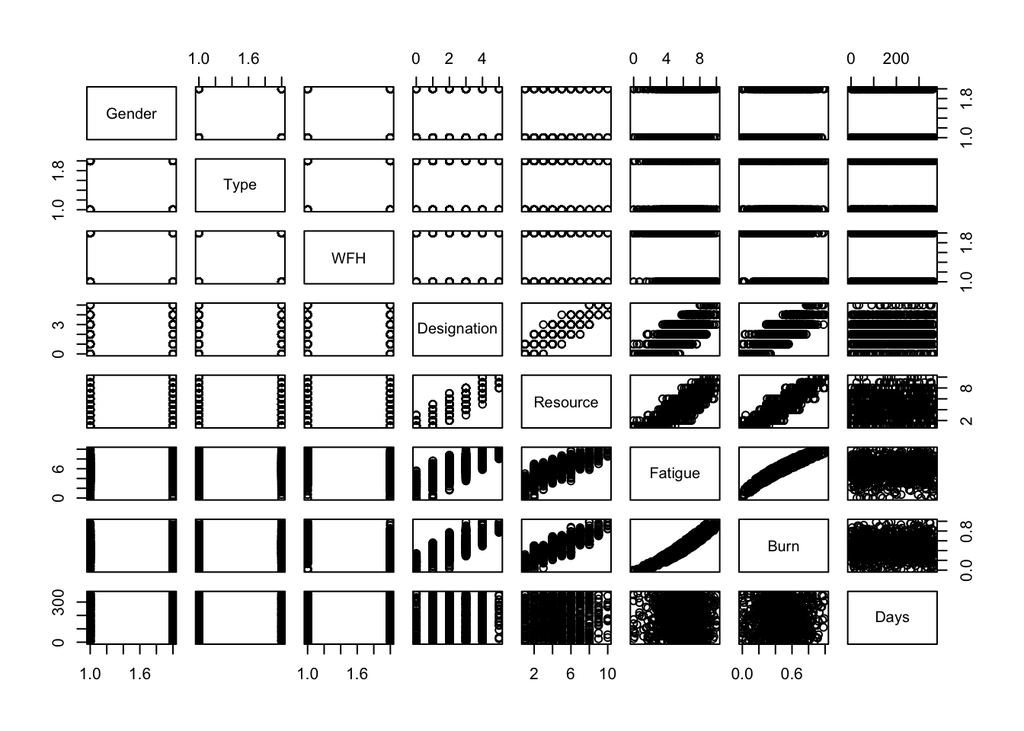

```r
pairs(train)
```

From the plot we identify `Designation` and `Resource` as having a the most obvious collinearity issues. We confirm this quantitatively by calculating the VIF (Variance Inflation Factor) for each predictor:

```r
sort(vif(mod_add), decreasing = TRUE)
```

```
##    Resource Designation     Fatigue      WFHYes  GenderMale TypeService
##    6.578795    4.597018    2.894669    1.128901    1.031927    1.003288
##        Days
##    1.001216
```

`Resource` is found to have a VIF $> 5$ (our typical ‘high VIF’ heuristic), and `Designation` is close behind with a VIF $> 4.5$.

So now we check `Designation` and `Resource` for correlation with respect to the rest of the predictors:

```r
mod_co = lm(Burn ~ . - Burn, data = train)            # all predictors
mod_co_De = lm(Burn ~ . - Designation, data = train)  # remove Designation
mod_co_Re = lm(Burn ~ . - Resource, data = train)     # remove Resource

cor(resid(mod_co_De), resid(mod_co))
```

```
## [1] 0.9992586
```

```r
cor(resid(mod_co_Re), resid(mod_co))
```

```
## [1] 0.9272661
```

The above result shows that `Designation` has higher collinearity with the rest predictors than `Resource`. Therefore we decide to refit the model without `Designation`.

```r
mod_add_2 = lm(Burn ~ . - Designation, data = train)
vif(mod_add_2)
```

```
##  GenderMale TypeService      WFHYes    Resource     Fatigue        Days
##    1.031570    1.003113    1.124479    2.907748    2.894652    1.001162
```

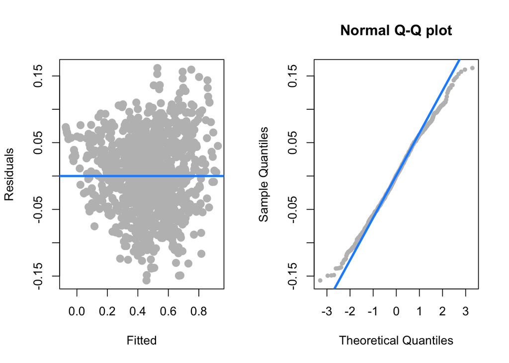

```
##         bptest shapiro.test adj.r.squared      loocv       BIC
## 1 3.743806e-05   0.01365506     0.9176786 0.05796589 -5661.298
```

```r
diagnostics(mod_add_2)
```

We see the updated model no longer has the collinearity issue we previously observed (all VIF $< 5$), but we see the ‘Equal Variance’ assumption is still violated at $\alpha = 0.10$.

### Variable Selection - Predictor Significance

Check possible relationships between categorical/discrete-valued numeric predictors and response ‘Burn’ via a boxplot.

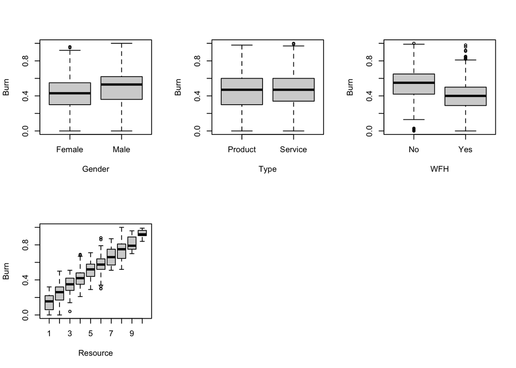

```r
par(mfrow = c(2, 3))
boxplot(Burn ~ Gender, data = train)
boxplot(Burn ~ Type, data = train)
boxplot(Burn ~ WFH, data = train)
boxplot(Burn ~ Resource, data = train)
```

From the boxplots we can qualitatively observe the following:  
1. `Gender` has some impact on `Burn`  
2. `Type` has minimal/no impact on `Burn`  
3. `WFH` has noticeable impact on `Burn`  
4. `Resource` has considerable impact on `Burn`

Comparing these findings with the `mod_add_2` coefficients above, they each mesh with their respective coefficient t-test p-values, where `Type` has no significant linear relationship with the response at $\alpha = 0.05$, and `Gender`, `WFH`, and `Resouce` all do.

```r
summary(mod_add_2)$coefficients
```

```
##                  Estimate   Std. Error     t value      Pr(>|t|)
## (Intercept) -9.033288e-02 0.0082008259 -11.0150960  1.056475e-26
## GenderMale   7.313219e-03 0.0037108168   1.9707841  4.902599e-02
## TypeService  2.503493e-03 0.0038284731   0.6539143  5.133184e-01
## WFHYes      -8.463978e-03 0.0038784283  -2.1823216  2.931954e-02
## Resource     2.636823e-02 0.0014846192  17.7609411  1.683148e-61
## Fatigue      7.426268e-02 0.0016102685  46.1181968 4.281844e-249
## Days        -5.466708e-06 0.0000171279  -0.3191697  7.496649e-01
```

Based on the above observations, we remove `Type` and `Days` from the model. The anova test confirms the corresponding null hypothesis: $H_0: \beta_{Type} = \beta_{Days} = 0$.

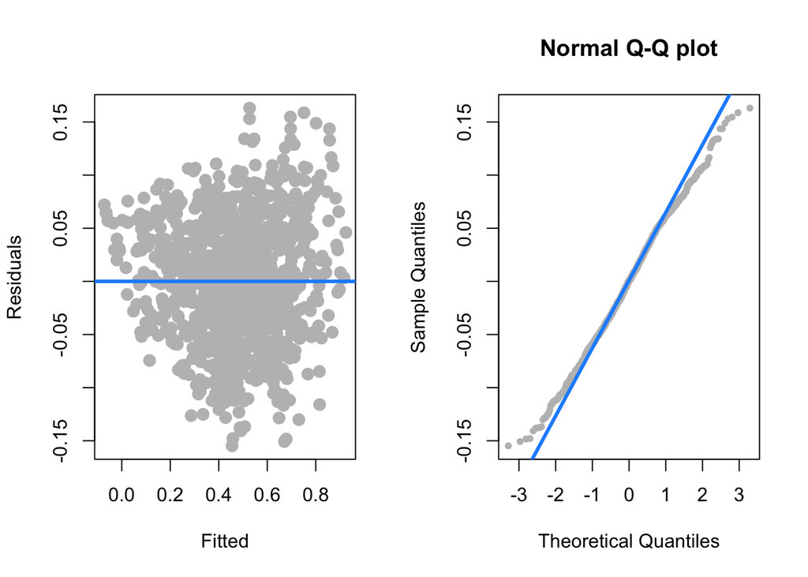

```
##         bptest shapiro.test adj.r.squared      loocv       BIC
## 1 1.715786e-05   0.01081688     0.9177998 0.05786238 -5674.575
```

```r
mod_add_3 = lm(Burn ~ Gender + WFH + Resource + Fatigue, data = train)
diagnostics(mod_add_3)
```

```r
anova(mod_add_3, mod_add_2)
```

```
## Analysis of Variance Table
##
## Model 1: Burn ~ Gender + WFH + Resource + Fatigue
## Model 2: Burn ~ (Gender + Type + WFH + Designation + Resource + Fatigue +
##     Days) - Designation
##   Res.Df    RSS Df Sum of Sq      F Pr(>F)
## 1    995 3.3156
## 2    993 3.3138  2 0.0017855 0.2675 0.7653
```

However this model still violates the ‘Equal Variance’ assumption at $\alpha = 0.01$.

### Transformations

Next, check for relationships between continuous numeric predictors and response via scatterplots.

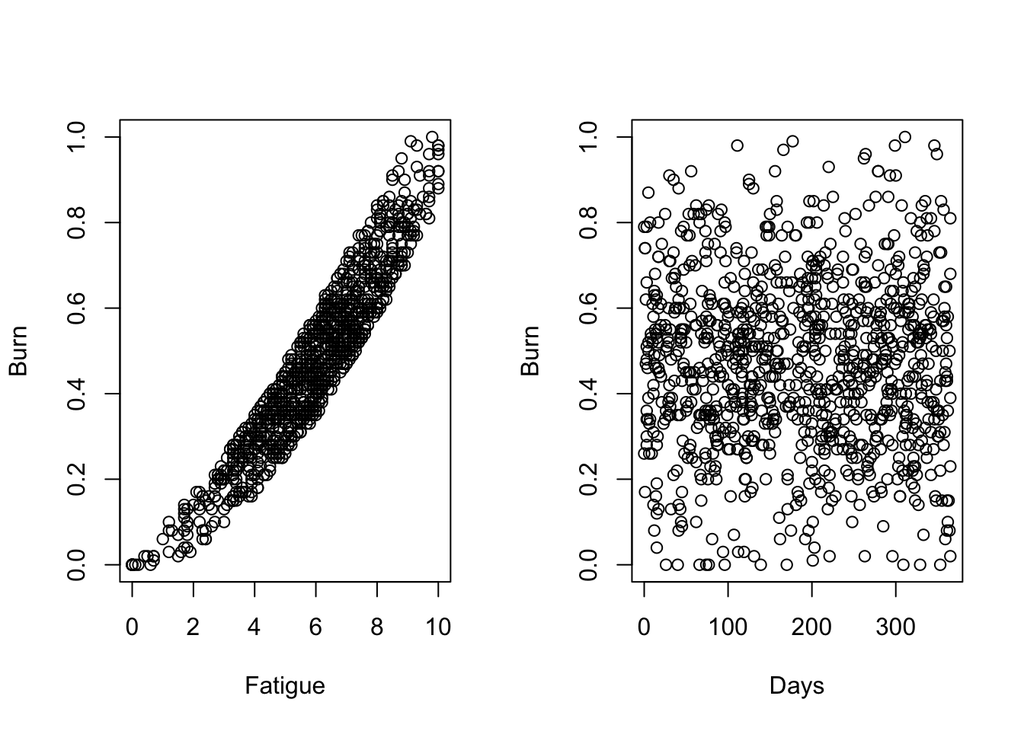

```r
par(mfrow = c(1, 2))
plot(Burn ~ Fatigue, data = train)
plot(Burn ~ Days, data = train)
```

From the plot, it’s clear that `Days` and the response have no linear relationship (which again, meshes with the t-test p-value for the coefficient).

However, we see the `Fatigue` predictor has a somewhat curved relationship with `Burn`. By applying different powers to the predictor, the following plots are obtained.

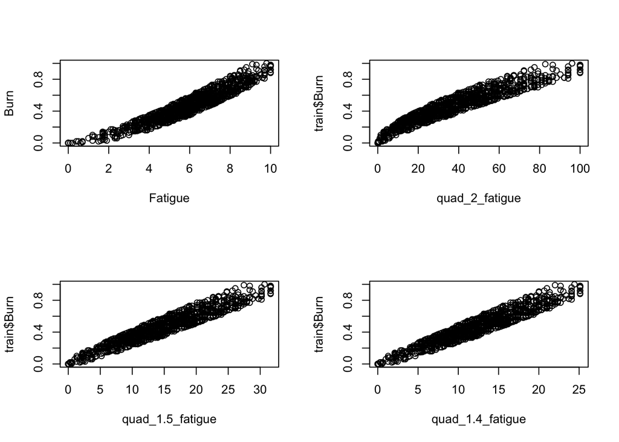

```r
par(mfrow = c(2, 2))
plot(Burn ~ Fatigue, data = train)
quad_2_fatigue = train$Fatigue ^ 2
plot(train$Burn ~ quad_2_fatigue)
quad_1.5_fatigue = train$Fatigue ^ 1.5
plot(train$Burn ~ quad_1.5_fatigue)
quad_1.4_fatigue = train$Fatigue ^ 1.4
plot(train$Burn ~ quad_1.4_fatigue)
```

We find the power of `1.4` is the sweet spot in making the relationship more linear.

We also observe that the variance increases with increasing `Fatigue`. We confirm this quantitatively by calculating the variance for `Fatigue` above the mean and below the mean.

```r
var(train$Fatigue[train$Fatigue > mean(train$Fatigue)])
```

```
## [1] 1.039997
```

```r
var(train$Fatigue < mean(train$Fatigue))
```

```
## [1] 0.2478468
```

Fit a new model adding an extra term of 1.4 power of `Fatigue`.

```r
mod_pow_1 = lm(Burn ~ Gender + WFH + Resource + Fatigue + I(Fatigue ^ 1.4), data = train)
diagnostics(mod_pow_1, plotit = FALSE)
```

```
##         bptest shapiro.test adj.r.squared      loocv       BIC
## 1 6.519916e-08  0.004286065     0.9212269 0.05663654 -5711.258
```

```r
anova(mod_add_3, mod_pow_1)
```

```
## Analysis of Variance Table
##
## Model 1: Burn ~ Gender + WFH + Resource + Fatigue
## Model 2: Burn ~ Gender + WFH + Resource + Fatigue + I(Fatigue^1.4)
##   Res.Df    RSS Df Sum of Sq      F    Pr(>F)
## 1    995 3.3156
## 2    994 3.1742  1   0.14142 44.287 4.678e-11 ***
## ---
## Signif. codes:  0 '***' 0.001 '**' 0.01 '*' 0.05 '.' 0.1 ' ' 1
```

We do see some marginal increase in adjusted r-squared in this model compared to the previous one and the anova test clearly favors the alternate model. However while the prior model did not violate the ‘Normality’ assumption, the Shapiro-Wilk test now fails at $\alpha = 0.01$.

### Influential Points

Start by identifying any influential points in our two current models of interest:

```r
add_mod_cd = cooks.distance(mod_add_3) > 4 / length(cooks.distance(mod_add_3))
pow_mod_cd = cooks.distance(mod_pow_1) > 4 / length(cooks.distance(mod_pow_1))
c("mod_add_3: ", sum(add_mod_cd), sum(add_mod_cd) / nrow(train) )
```

```
## [1] "mod_add_3: " "38"          "0.038"
```

```r
c("mod_pow_1: ", sum(pow_mod_cd), sum(pow_mod_cd) / nrow(train) )
```

```
## [1] "mod_pow_1: " "30"          "0.03"
```

Each model has a relatively small number and proportion of influential points; we’re comfortable experimenting with dropping them.

Influential points in both models are excluded so that models could be refit on the same data and compared via anova test if they show promise. Refit and re-evaluate:

```r
mod_pow_2 = lm(Burn ~ Gender + WFH + Resource + Fatigue + I(Fatigue ^ 1.4),
               data = train,
               subset = pow_mod_cd & add_mod_cd)
diagnostics(mod_pow_2, plotit = FALSE)
```

```
##      bptest shapiro.test adj.r.squared     loocv       BIC
## 1 0.1150586    0.1363189     0.8645497 0.1080188 -114.0064
```

```r
mod_add_4 = lm(Burn ~ Gender + WFH + Resource + Fatigue,
               data = train,
               subset = pow_mod_cd & add_mod_cd)
diagnostics(mod_add_4, plotit = FALSE)
```

```
##       bptest shapiro.test adj.r.squared     loocv       BIC
## 1 0.07303267    0.1717868     0.8702152 0.1010884 -117.1998
```

This modified additive model has traded meeting the ‘Normality’ assumption for now instead meeting the ‘Equal Variance’ assumption.

### Interactions, BIC, AIC

Next, let’s continue our model search by applying backwards BIC to a larger model fitted with all predictors and all possible first-order interaction terms.

```r
mod_all = lm(Burn ~ . ^ 2, data = train)

mod_bic_back = step(mod_all, trace = 0, k = log(length(resid(mod_all))))
mod_bic_back$call$formula
```

```
## Burn ~ Resource + Fatigue + Resource:Fatigue
```

The model selected by backwards BIC is quite simplistic, with only has two predictors and their interaction. Checking the metrics, this model also violates the ‘Equal Variance’ and ‘Normality’ assumptions at $\alpha = 0.10$.

```r
diagnostics(mod_bic_back, plotit = FALSE)
```

```
##         bptest shapiro.test adj.r.squared      loocv       BIC
## 1 2.344005e-07  0.001816515     0.9212792 0.05657429 -5723.728
```

Since backwards BIC appears to have eliminated too many terms and potentially oversimplified the model, we’ll also try backwards AIC:

```r
mod_aic_back = step(mod_all, trace = 0)
mod_aic_back$call$formula
```

```
## Burn ~ Gender + WFH + Designation + Resource + Fatigue + Designation:Fatigue +
##     Resource:Fatigue
```

```r
diagnostics(mod_aic_back, plotit = FALSE)
```

```
##        bptest shapiro.test adj.r.squared      loocv       BIC
## 1 8.38451e-06  0.005655967     0.9220405 0.05638996 -5709.839
```

However, this model also violates the ‘Equal Variance’ and ‘Normality’ assumptions at $\alpha = 0.10$.

Try removing influential points again:

```r
bic_mod_cd = cooks.distance(mod_bic_back) > 4 / length(cooks.distance(mod_bic_back))
aic_mod_cd = cooks.distance(mod_aic_back) > 4 / length(cooks.distance(mod_aic_back))
c("mod_bic_back: ", sum(bic_mod_cd), sum(bic_mod_cd) / nrow(train) )
```

```
## [1] "mod_bic_back: " "32"             "0.032"
```

```r
c("mod_aic_back: ", sum(aic_mod_cd), sum(aic_mod_cd) / nrow(train) )
```

```
## [1] "mod_aic_back: " "25"             "0.025"
```

Again, each model has a relatively small number and proportion of influential points; we’re comfortable experimenting with dropping them.

Refit and re-evaluate:

```r
bic_mod_cd = cooks.distance(mod_bic_back) < 4 / length(cooks.distance(mod_bic_back))
aic_mod_cd = cooks.distance(mod_aic_back) < 4 / length(cooks.distance(mod_aic_back))

mod_bic_back_2 = lm(Burn ~ Resource + Fatigue + Resource:Fatigue, data = train,
                        subset = bic_mod_cd & aic_mod_cd)
mod_aic_back_2 = lm(Burn ~ Gender + WFH + Designation + Resource + Fatigue +
                        Designation:Fatigue + Resource:Fatigue, data = train,
                        subset = bic_mod_cd & aic_mod_cd)

diagnostics(mod_bic_back_2, plotit=FALSE)
```

```
##         bptest shapiro.test adj.r.squared      loocv       BIC
## 1 4.745736e-05 6.471761e-05     0.9242889 0.05322132 -5616.532
```

```r
diagnostics(mod_aic_back_2, plotit=FALSE)
```

```
##         bptest shapiro.test adj.r.squared      loocv      BIC
## 1 0.0002894262 0.0002966055      0.925123 0.05301145 -5603.73
```

Neither the backwards BIC or backwards AIC is able to meet either the ‘Equal Variance’ or ‘Normality’ assumptions at $\alpha = 0.10$ through removal of influential points.

With this we conclude our model search.

# Results

Below is a summary of all the models fitted during our model search:

```r
model_list = list(mod_add, mod_add_2, mod_add_3, mod_add_4,
                  mod_pow_1, mod_pow_2,
                  mod_bic_back, mod_aic_back, mod_bic_back_2, mod_aic_back_2 )
metrics_table = matrix(ncol = 5, nrow = 0)
formulas = rep('', length(model_list))
for (i in 1:length(model_list)) {
  formulas[i] = toString(model_list[[i]]$call$formula)
  temp_row = unlist(diagnostics(model_list[[i]], plotit = FALSE))
  metrics_table = rbind(metrics_table, temp_row)
}
colnames(metrics_table) = c('BP Test', 'Shapiro Test', 'Adj R.sq', 'LOOCV', 'BIC')
rownames(metrics_table) = formulas
kable(metrics_table)
```

|  | BP Test | Shapiro Test | Adj R.sq | LOOCV | BIC |
| --- | --- | --- | --- | --- | --- |
| ~, Burn, . | 0.0000578 | 0.0168097 | 0.9177178 | 0.0579716 | -5655.8738 |
| ~, Burn, . - Designation | 0.0000374 | 0.0136551 | 0.9176786 | 0.0579659 | -5661.2981 |
| ~, Burn, Gender + WFH + Resource + Fatigue | 0.0000172 | 0.0108169 | 0.9177998 | 0.0578624 | -5674.5749 |
| ~, Burn, Gender + WFH + Resource + Fatigue | 0.0730327 | 0.1717868 | 0.8702152 | 0.1010884 | -117.1998 |
| ~, Burn, Gender + WFH + Resource + Fatigue + I(Fatigue^1.4) | 0.0000001 | 0.0042861 | 0.9212269 | 0.0566365 | -5711.2577 |
| ~, Burn, Gender + WFH + Resource + Fatigue + I(Fatigue^1.4) | 0.1150586 | 0.1363189 | 0.8645497 | 0.1080188 | -114.0064 |
| ~, Burn, Resource + Fatigue + Resource:Fatigue | 0.0000002 | 0.0018165 | 0.9212792 | 0.0565743 | -5723.7281 |
| ~, Burn, Gender + WFH + Designation + Resource + Fatigue + Designation:Fatigue + Resource:Fatigue | 0.0000084 | 0.0056560 | 0.9220405 | 0.0563900 | -5709.8386 |
| ~, Burn, Resource + Fatigue + Resource:Fatigue | 0.0000475 | 0.0000647 | 0.9242889 | 0.0532213 | -5616.5320 |
| ~, Burn, Gender + WFH + Designation + Resource + Fatigue + Designation:Fatigue + Resource:Fatigue | 0.0002894 | 0.0002966 | 0.9251230 | 0.0530114 | -5603.7302 |

Unfortunately, our model search yielded no model that could fulfill the ‘Equal Variance’ and ‘Normality’ assumptions concurrently, so we must make tradeoffs between these two assumptions. We believe that this persistence of the ‘Equal Variance’ assumption violation is mostly likely because the variance is a function of`Fatigue`, as observed previously in this plot:

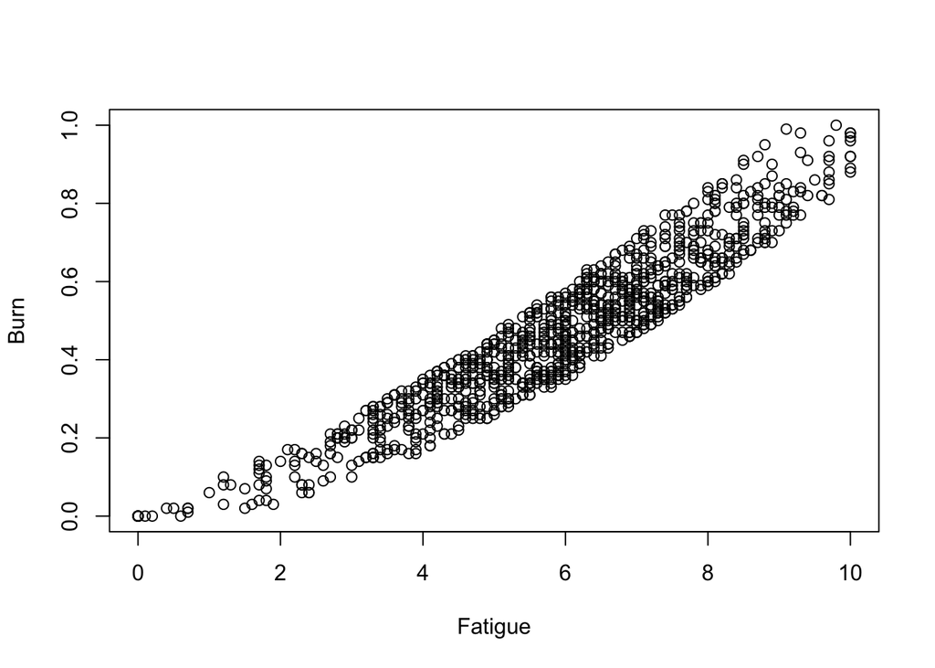

```r
plot(Burn ~ Fatigue, data = train)
```

Interestingly, most of our models meet our modeling goal of Adjusted R-Squared > 90%, and are in fact clustered tightly between 91.7% - 92.5%. This gives us a lot of leeway in which model can otherwise ‘best’ fulfill the remaining three modeling goals.

We’ll look at a reduced metrics table with only those models that meet three of the four modeling criteria:

```r
model_list = list(mod_add, mod_add_2, mod_add_3)
metrics_table = matrix(ncol = 5, nrow = 0)
formulas = rep('', length(model_list))
for (i in 1:length(model_list)) {
  formulas[i] = toString(model_list[[i]]$call$formula)
  temp_row = unlist(diagnostics(model_list[[i]], plotit = FALSE))
  metrics_table = rbind(metrics_table, temp_row)
}
colnames(metrics_table) = c('BP Test', 'Shapiro Test', 'Adj R.sq', 'LOOCV', 'BIC')
rownames(metrics_table) = formulas
kable(metrics_table)
```

|  | BP Test | Shapiro Test | Adj R.sq | LOOCV | BIC |
| --- | --- | --- | --- | --- | --- |
| ~, Burn, . | 5.78e-05 | 0.0168097 | 0.9177178 | 0.0579716 | -5655.874 |
| ~, Burn, . - Designation | 3.74e-05 | 0.0136551 | 0.9176786 | 0.0579659 | -5661.298 |
| ~, Burn, Gender + WFH + Resource + Fatigue | 1.72e-05 | 0.0108169 | 0.9177998 | 0.0578624 | -5674.575 |

Anova test for all three models:

```r
anova(mod_add_3, mod_add_2, mod_add)
```

```
## Analysis of Variance Table
##
## Model 1: Burn ~ Gender + WFH + Resource + Fatigue
## Model 2: Burn ~ (Gender + Type + WFH + Designation + Resource + Fatigue +
##     Days) - Designation
## Model 3: Burn ~ Gender + Type + WFH + Designation + Resource + Fatigue +
##     Days
##   Res.Df    RSS Df Sum of Sq      F Pr(>F)
## 1    995 3.3156
## 2    993 3.3138  2 0.0017855 0.2676 0.7652
## 3    992 3.3089  1 0.0049122 1.4727 0.2252
```

```r
#anova(mod_add, mod_add_3)
```

Since the Fitted vs. Residual plot, Normal Q-Q plot, and Adjusted R-squared for each of these models is virtually identical (see previous plots in Methods section), and the anova test prefers the simplest model, we choose `mod_3_add`, an additive model of `Gender`, `WFH` `Resource`, and `Fatigue`, as the model that best fulfills our initial modeling goals.

Finally, we fit the selected model to the complete data set:

```r
mod_final = lm(Burn ~ Gender + WFH + Resource + Fatigue, data = train_complete)
summary(mod_final)
```

```
##
## Call:
## lm(formula = Burn ~ Gender + WFH + Resource + Fatigue, data = train_complete)
##
## Residuals:
##       Min        1Q    Median        3Q       Max
## -0.156953 -0.041084 -0.000499  0.040699  0.201211
##
## Coefficients:
##               Estimate Std. Error t value Pr(>|t|)
## (Intercept) -0.0848754  0.0015438 -54.977  < 2e-16 ***
## GenderMale   0.0045675  0.0008293   5.508 3.69e-08 ***
## WFHYes      -0.0117739  0.0008602 -13.688  < 2e-16 ***
## Resource     0.0262190  0.0003355  78.155  < 2e-16 ***
## Fatigue      0.0739452  0.0003566 207.369  < 2e-16 ***
## ---
## Signif. codes:  0 '***' 0.001 '**' 0.01 '*' 0.05 '.' 0.1 ' ' 1
##
## Residual standard error: 0.05579 on 18585 degrees of freedom
## Multiple R-squared:  0.9205, Adjusted R-squared:  0.9205
## F-statistic: 5.379e+04 on 4 and 18585 DF,  p-value: < 2.2e-16
```

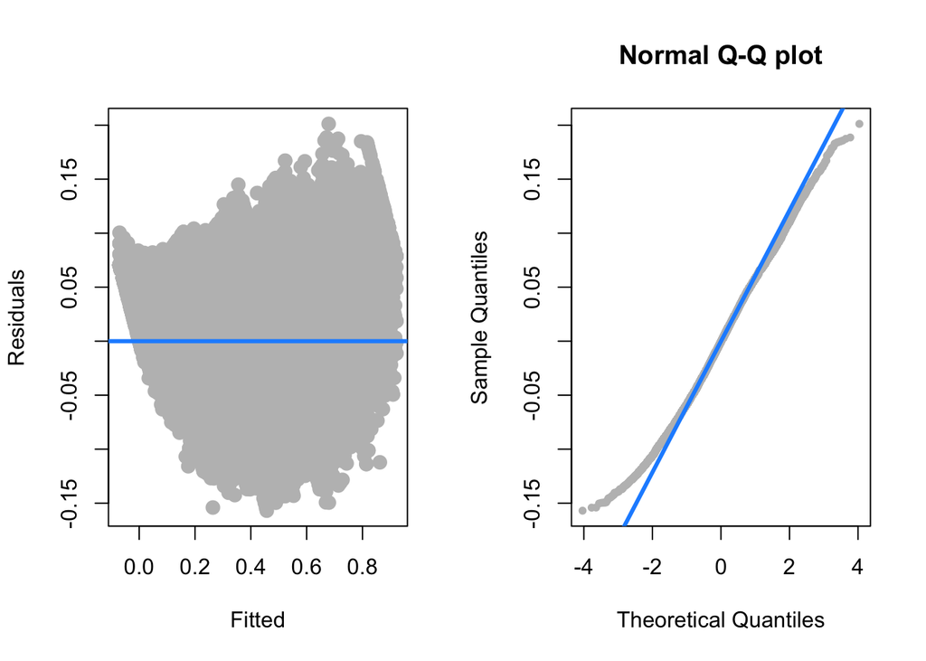

```r
diagnostics(mod_final, testit = FALSE)
```

# Discussion

Our chosen model gives us the ability to make reliable predictions of an employee’s level of burnout. Since it violates the ‘Equal Variance’ assumption, it must be used with the caveat that predictions will be somewhat less accurate for employees reporting higher Mental Fatigue Scores.

Because the model is so simple, we are able to make the following recommendations to companies and individuals interested in combatting burnout:

- Gender: Males are somewhat more prone to burnout, and should perhaps take extra precautions against it.
- Work From Home: Availability of an appropriate work-from-home setup is associated with lower burnout. Whether this is an issue of correlation or causation is beyond the scope of this analysis; perhaps it is not the simple availability of such setups that drives the effect, but that companies with better work/life balance cultures are more likely to offer an appropriate WFH setup. But regardless of the effect direction, employers should seek to provide a WFH setup (or perhaps foster a company culture where that is normal and accepted), and employees can be advised to seek companies that do so.
- Resource Allocation: More hours allocated to work today is associated with higher burnout. Both employers and employees can be advised to avoid excessive work hours.
- Mental Fatigue Score: A higher self-reported stress level is associated with higher burnout. Employers should regularly and actively assess employee mental fatigue levels, and take action to reduce it when it is found to be high. In the absence of this employer intervention, employees should self-asses their own mental fatigue level, and take the necessary steps to alleviate it before it escalates to full burnout.

A final word about the violated ‘Equal Variance’ assumption. Above we’ve discussed how a higher mental fatigue score is indicative of a higher level of burnout. Therefore we can also conclude that a person with a high mental fatigue score is already known to be at increased risk of burnout, and interventions should be taken in that case, regardless of the exact predicted burnout score.

# Appendix

**All code in this appendix shows the inital data cleaning process**

Read in, view

```r
#read in data
burnout_orig = read_csv("train.csv")
#create copy to edit
burnout_cl = burnout_orig

#check structure of as-read
str(burnout_orig)
```

```
## spec_tbl_df [22,750 × 9] (S3: spec_tbl_df/tbl_df/tbl/data.frame)
##  $ Employee ID         : chr [1:22750] "fffe32003000360033003200" "fffe3700360033003500" "fffe31003300320037003900" "fffe32003400380032003900" ...
##  $ Date of Joining     : Date[1:22750], format: "2008-09-30" "2008-11-30" ...
##  $ Gender              : chr [1:22750] "Female" "Male" "Female" "Male" ...
##  $ Company Type        : chr [1:22750] "Service" "Service" "Product" "Service" ...
##  $ WFH Setup Available : chr [1:22750] "No" "Yes" "Yes" "Yes" ...
##  $ Designation         : num [1:22750] 2 1 2 1 3 2 3 2 3 3 ...
##  $ Resource Allocation : num [1:22750] 3 2 NA 1 7 4 6 4 6 6 ...
##  $ Mental Fatigue Score: num [1:22750] 3.8 5 5.8 2.6 6.9 3.6 7.9 4.4 NA NA ...
##  $ Burn Rate           : num [1:22750] 0.16 0.36 0.49 0.2 0.52 0.29 0.62 0.33 0.56 0.67 ...
##  - attr(*, "spec")=
##   .. cols(
##   ..   `Employee ID` = col_character(),
##   ..   `Date of Joining` = col_date(format = ""),
##   ..   Gender = col_character(),
##   ..   `Company Type` = col_character(),
##   ..   `WFH Setup Available` = col_character(),
##   ..   Designation = col_double(),
##   ..   `Resource Allocation` = col_double(),
##   ..   `Mental Fatigue Score` = col_double(),
##   ..   `Burn Rate` = col_double()
##   .. )
```

Examine, clean each field

`Employee ID`  
Index field, it’s dropped because it’s not relevant to burn rate.

`Date of joining`

Convert date format to numeric ‘Days in Org’; drop original

```r
#dataset goes from 1/1/2008 to 12/31/2008
min(burnout_orig$"Date of Joining")
```

```
## [1] "2008-01-01"
```

```r
max(burnout_orig$"Date of Joining")
```

```
## [1] "2008-12-31"
```

```r
end_date = max(burnout_orig$"Date of Joining")

burnout_cl$"Days in Org" = as.numeric(end_date -
                                        burnout_orig$"Date of Joining")
burnout_cl$"Days in Org"[1:24]
```

```
##  [1]  92  31 296  58 160  35 364  61   4 297 290 233 346 312 231 332 289 278 216
## [20] 187 122 351 241  44
```

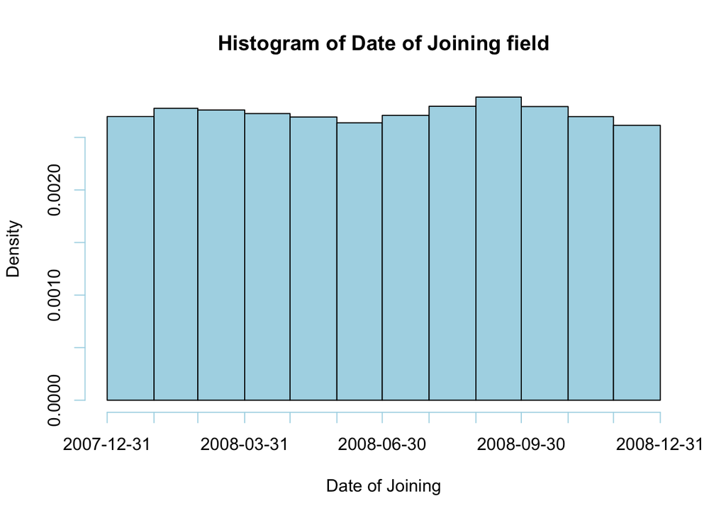

```r
hist(burnout_cl$"Date of Joining", col = "lightblue",
     main = "Histogram of Date of Joining field",
     breaks = 'months',
     xlab = "Date of Joining" )
```

```r
# remove 'Date of Joining'
burnout_cl = burnout_cl[-2]
```

`Gender`

Only 2 unique values; should be a factor

```r
unique(burnout_orig$"Gender")
```

```
## [1] "Female" "Male"
```

```r
is.factor(burnout_orig$"Gender")
```

```
## [1] FALSE
```

```r
burnout_cl$"Gender" = as.factor(burnout_orig$"Gender")
is.factor(burnout_cl$"Gender")
```

```
## [1] TRUE
```

`Company Type`

Only 2 unique values; should be a factor

```r
unique(burnout_orig$"Company Type")
```

```
## [1] "Service" "Product"
```

```r
is.factor(burnout_orig$"Company Type")
```

```
## [1] FALSE
```

```r
burnout_cl$"Company Type" = as.factor(burnout_orig$"Company Type")
is.factor(burnout_cl$"Company Type")
```

```
## [1] TRUE
```

`WFH Setup Available`

Only 2 unique values; should be a factor

```r
unique(burnout_orig$"WFH Setup Available")
```

```
## [1] "No"  "Yes"
```

```r
is.factor(burnout_orig$"WFH Setup Available")
```

```
## [1] FALSE
```

```r
burnout_cl$"WFH Setup Available" = as.factor(burnout_orig$"WFH Setup Available")
is.factor(burnout_cl$"WFH Setup Available")
```

```
## [1] TRUE
```

The remainder of the fields are all numerical values where, per the data dictionary, the values (whether continuous or integer) exist on a scale (eg higher Designation value translates to higher in the organization). Therefore, for these fields we will be checking distributions and examining/handling NA’s.

`Designation`  
No NA’s; no cleaning action needed

```r
unique(burnout_orig$"Designation")
```

```
## [1] 2 1 3 0 4 5
```

```r
sum(is.na(burnout_orig$"Designation"))
```

```
## [1] 0
```

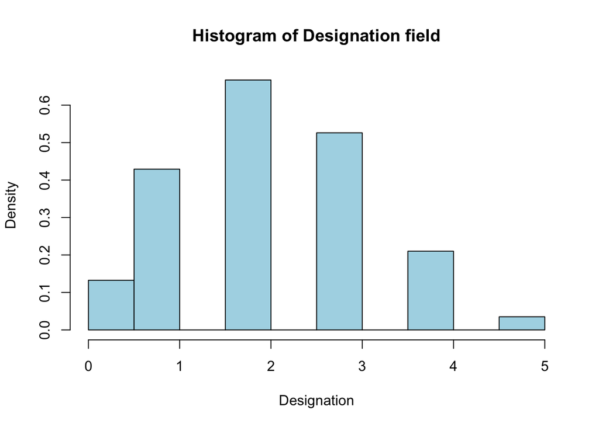

```r
hist(burnout_cl$"Designation", col = "lightblue", probability = TRUE,
     main = "Histogram of Designation field",
     xlab = "Designation" )
```

`Resource Allocation`

Proportion of NA’s deemed acceptable for modeling

```r
unique(burnout_orig$"Resource Allocation")
```

```
##  [1]  3  2 NA  1  7  4  6  5  8 10  9
```

```r
sum(is.na(burnout_orig$"Resource Allocation"))
```

```
## [1] 1381
```

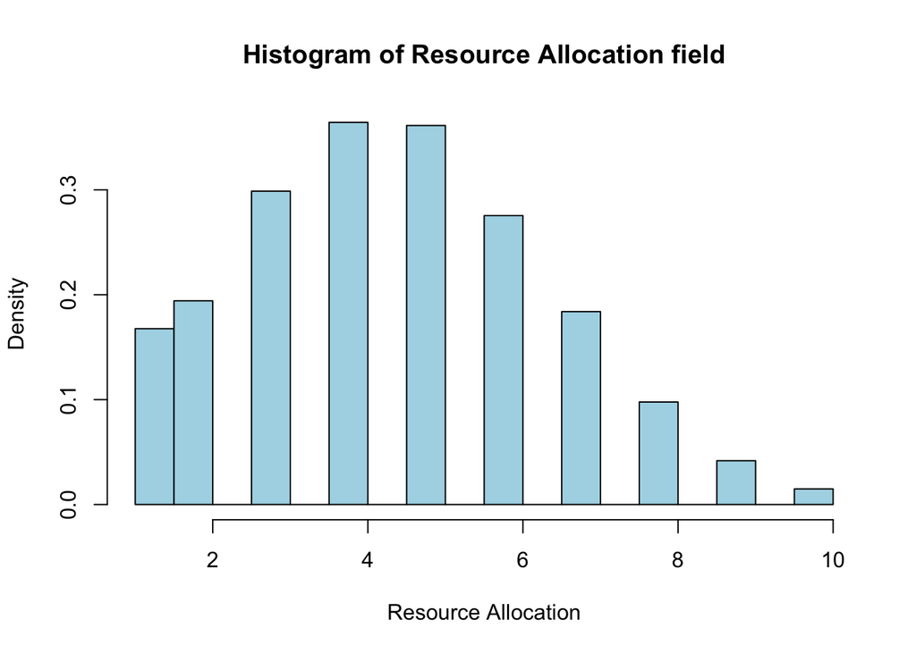

```r
ra_na_proportion = sum(is.na(burnout_orig$"Resource Allocation")) /
                            nrow(burnout_orig)

hist(burnout_cl$"Resource Allocation", col = "lightblue", probability = TRUE,
     main = "Histogram of Resource Allocation field",
     xlab = "Resource Allocation")
```

6.07% of `Resource Allocation` values are NA.

`Mental Fatigue Score`

Proportion of NA’s deemed acceptable for modeling

```r
sum(is.na(burnout_orig$"Mental Fatigue Score"))
```

```
## [1] 2117
```

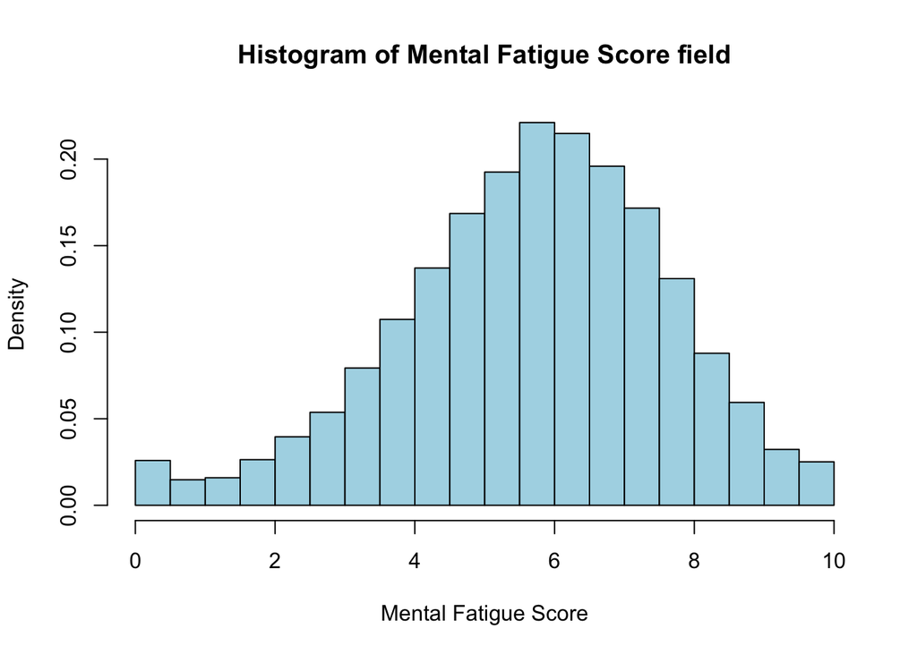

```r
mf_na_proportion = sum(is.na(burnout_orig$"Mental Fatigue Score")) /
                            nrow(burnout_orig)

hist(burnout_cl$"Mental Fatigue Score", col = "lightblue", probability = TRUE,
     main = "Histogram of Mental Fatigue Score field",
     xlab = "Mental Fatigue Score")
```

9.31% of `Mental Fatigue Score` values are NA.

`Burn Rate`  
Records with no target value for the target field are of no use for training.  
Should drop these records.

```r
sum(is.na(burnout_orig$"Burn Rate"))
```

```
## [1] 1124
```

```r
br_na_proportion = sum(is.na(burnout_orig$"Burn Rate")) /
                            nrow(burnout_orig)
```

4.94% of `Burn Rate` values are NA.

```r
burnout_cl = burnout_cl[!is.na(burnout_orig$"Burn Rate"), ]
#confirm drop
sum(is.na(burnout_cl$"Burn Rate"))
```

```
## [1] 0
```

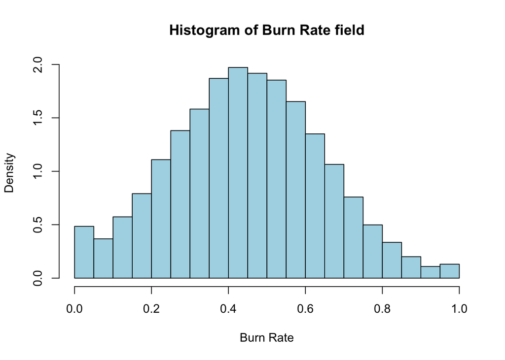

```r
hist(burnout_cl$"Burn Rate", col = "lightblue", probability = TRUE,
     main = "Histogram of Burn Rate field",
     xlab = "Burn Rate")
```

Cleaning Wrap-up

After dropping the records with `Burn Rate` NA, we should recalculate the NA proportions we calculated above.

```r
recalc_mf_na_proportion = sum(is.na(burnout_cl$"Mental Fatigue Score")) /
                            nrow(burnout_cl)
recalc_ra_na_proportion = sum(is.na(burnout_cl$"Resource Allocation")) /
                            nrow(burnout_cl)
```

After dropping, 5.91% of `Resource Allocation` values are NA.  
After dropping, 8.99% of `Mental Fatigue Score` values are NA.

Final look at the cleaned dataset:

```r
str(burnout_cl)
```

```
## tibble [21,626 × 9] (S3: tbl_df/tbl/data.frame)
##  $ Employee ID         : chr [1:21626] "fffe32003000360033003200" "fffe3700360033003500" "fffe31003300320037003900" "fffe32003400380032003900" ...
##  $ Gender              : Factor w/ 2 levels "Female","Male": 1 2 1 2 1 2 1 1 1 1 ...
##  $ Company Type        : Factor w/ 2 levels "Product","Service": 2 2 1 2 2 1 2 2 2 1 ...
##  $ WFH Setup Available : Factor w/ 2 levels "No","Yes": 1 2 2 2 1 2 1 2 1 1 ...
##  $ Designation         : num [1:21626] 2 1 2 1 3 2 3 2 3 3 ...
##  $ Resource Allocation : num [1:21626] 3 2 NA 1 7 4 6 4 6 6 ...
##  $ Mental Fatigue Score: num [1:21626] 3.8 5 5.8 2.6 6.9 3.6 7.9 4.4 NA NA ...
##  $ Burn Rate           : num [1:21626] 0.16 0.36 0.49 0.2 0.52 0.29 0.62 0.33 0.56 0.67 ...
##  $ Days in Org         : num [1:21626] 92 31 296 58 160 35 364 61 4 297 ...
```

```r
#running a basic model to check that cleaning yielded a usable dataset
test = lm(`Burn Rate` ~ `Days in Org` + Gender + `Company Type` + `WFH Setup Available`
                + Designation + `Resource Allocation` + `Mental Fatigue Score`,
   data = burnout_cl, na.action = na.exclude)
summary(test)
```

```
##
## Call:
## lm(formula = `Burn Rate` ~ `Days in Org` + Gender + `Company Type` +
##     `WFH Setup Available` + Designation + `Resource Allocation` +
##     `Mental Fatigue Score`, data = burnout_cl, na.action = na.exclude)
##
## Residuals:
##      Min       1Q   Median       3Q      Max
## -0.15670 -0.04101 -0.00033  0.04053  0.20203
##
## Coefficients:
##                            Estimate Std. Error t value Pr(>|t|)
## (Intercept)              -8.528e-02  1.786e-03 -47.738  < 2e-16 ***
## `Days in Org`             6.290e-07  3.883e-06   0.162    0.871
## GenderMale                4.441e-03  8.288e-04   5.358 8.50e-08 ***
## `Company Type`Service     4.784e-04  8.600e-04   0.556    0.578
## `WFH Setup Available`Yes -1.157e-02  8.599e-04 -13.459  < 2e-16 ***
## Designation              -4.761e-03  7.547e-04  -6.309 2.88e-10 ***
## `Resource Allocation`     2.860e-02  5.053e-04  56.606  < 2e-16 ***
## `Mental Fatigue Score`    7.388e-02  3.564e-04 207.286  < 2e-16 ***
## ---
## Signif. codes:  0 '***' 0.001 '**' 0.01 '*' 0.05 '.' 0.1 ' ' 1
##
## Residual standard error: 0.05574 on 18582 degrees of freedom
##   (3036 observations deleted due to missingness)
## Multiple R-squared:  0.9207, Adjusted R-squared:  0.9206
## F-statistic: 3.081e+04 on 7 and 18582 DF,  p-value: < 2.2e-16
```

Renaming column names for easier manipulation

```r
colnames(burnout_cl) = c('ID', 'Gender', 'Type', 'WFH', 'Designation', 'Resource', 'Fatigue', 'Burn', 'Days')
str(burnout_cl)
```

```
## tibble [21,626 × 9] (S3: tbl_df/tbl/data.frame)
##  $ ID         : chr [1:21626] "fffe32003000360033003200" "fffe3700360033003500" "fffe31003300320037003900" "fffe32003400380032003900" ...
##  $ Gender     : Factor w/ 2 levels "Female","Male": 1 2 1 2 1 2 1 1 1 1 ...
##  $ Type       : Factor w/ 2 levels "Product","Service": 2 2 1 2 2 1 2 2 2 1 ...
##  $ WFH        : Factor w/ 2 levels "No","Yes": 1 2 2 2 1 2 1 2 1 1 ...
##  $ Designation: num [1:21626] 2 1 2 1 3 2 3 2 3 3 ...
##  $ Resource   : num [1:21626] 3 2 NA 1 7 4 6 4 6 6 ...
##  $ Fatigue    : num [1:21626] 3.8 5 5.8 2.6 6.9 3.6 7.9 4.4 NA NA ...
##  $ Burn       : num [1:21626] 0.16 0.36 0.49 0.2 0.52 0.29 0.62 0.33 0.56 0.67 ...
##  $ Days       : num [1:21626] 92 31 296 58 160 35 364 61 4 297 ...
```

Test write out/read back in

```r
#Does not read back in the same as it was written out
#It appears we need to preface the modeling script with a condensed version of
#this cleaning script (or set params on the read_csv call to make it match)

#write_csv(burnout_cl, "train_cleaned.csv")
#reread = read_csv("train_cleaned.csv")
#all.equal(burnout_cl, reread)
```

**This analysis was prepared by Eric Yan and Rachel Brynsvold**